# Lesson 3. Missing values

## 5. Manipulation of variables

**Introduction**

In the case of working with R, the adjustment of the variables goes through attending to the different type of structure, usually numerical (vector) or categorical variable (factor). This definition establishes clear differences; for example, an average cannot be made with a factor, and numerical vectors do not have labels.

To see the most basic procedures, please go to **Lesson 1**

## 6. Data Manipulation

Now, let’s review the exercise from last class. You must open your R codes where you performed the procedures. In case you have not done them, please open the R script called **Exercise 2**.

## 7. Missing data

**Introduction**

Methods for analyzing missing data require assumptions about the nature of the data and the reasons why it is incomplete. This requires a description of the **lost data patterns**.

Then, the most used methods to treat the lost data are

- Eliminate missing data: work with complete or available cases
- Lost data imputation: mean, regression, LOFC, multiple and random

### 8.1 Missing Data Patterns

Often the amount of data lost is not so important, but the distribution of the lost data is. This involves describing the possible relationships between the measured variables and the probability of missing data

The most known distribution patterns are: univariate pattern, non-response unit pattern, monotonic pattern, general pattern, planned missing pattern and latent variable pattern.

To address the structure of missing data we will use the `VIM` library. Initially we can explore the missing data:

1. Count the total number of NAs in the database

```r
sum(is.na(nhanes))
```

```
## [1] 15161
```

```r
#15161 NAs
```

2. Know the number of NAs per column

```r
colSums(is.na(nhanes))
```

```
##          id      gender      dpills calciumvitd       folic      dysldl
##           0           0        1392        1644        1644        7070
##       start         end   treatment   HCQ_dosis
##        1116        1456         367         472
```

#### **Classification of lost data**

- **MCAR (Missing Completely At Random):** The probability that a response to a variable is missing data is independent of both the value of this variable and the value of other variables in the data set.
- **MAR (Missing At Random):** The probability that a response is missing data is independent of the values of the same variable but is dependent on the values of other variables in the data set.
- **NMAR (Not Missing At Random):** The probability that a response to a variable is missing data is dependent on the values of the variable.

To address missing data distribution in R we are going to use `aggr` function from `VIM` library. This plot the amount of missing/imputed values in each variable and the amount of missing/imputed values in certain combinations of variables.

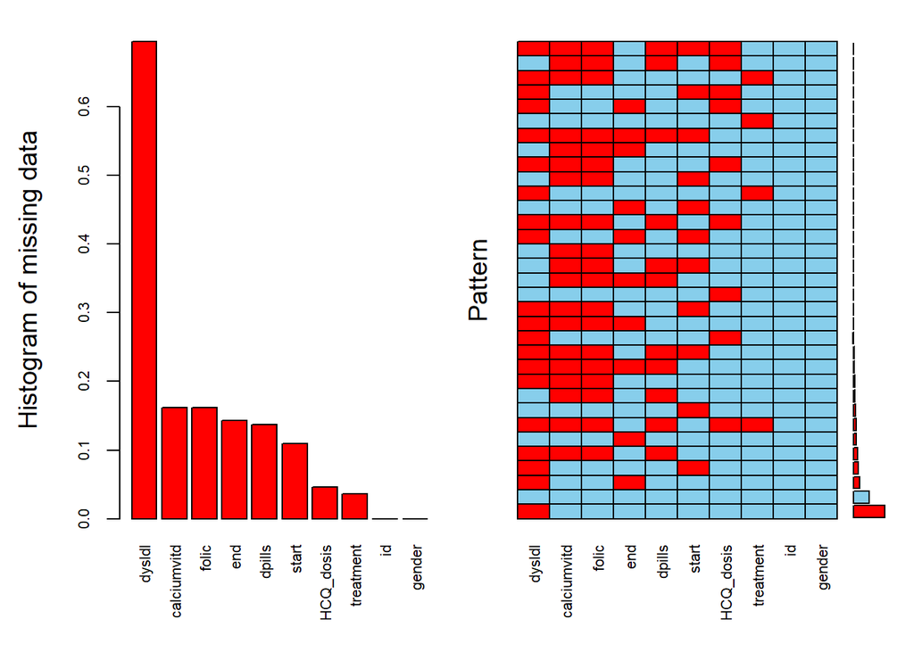

```
##
##  Variables sorted by number of missings:
##     Variable      Count
##       dysldl 0.69484029
##  calciumvitd 0.16157248
##        folic 0.16157248
##          end 0.14309582
##       dpills 0.13680590
##        start 0.10968059
##    HCQ_dosis 0.04638821
##    treatment 0.03606880
##           id 0.00000000
##       gender 0.00000000
```

```r
aggr_plot <- aggr(nhanes,numbers=TRUE,sortVar=TRUE, labels= names(nhanes), cex.axis=.7, gap=3, ylab=c("Histogram of missing data","Pattern"))
```

### 8.2 Listwise deletion or Complete case analysis

- Omit records or observations
- Problems
  - The models are without ANS and differences in coefficients occur
  - The population cannot be generalized
  - Produces an insufficient amount of records

**Excluding Missing Values from Analyses**

1. Arithmetic functions on missing values yield missing values.

```r
mean(nhanes$calciumvitd) # returns NA
```

```
## [1] NA
```

```r
mean(nhanes$calciumvitd, na.rm=TRUE) # returns 2.638
```

```
## [1] 2.638139
```

2. The function **complete.cases()** returns a logical vector indicating which cases are complete. List rows of data that have missing values
3. The function **na.omit()** returns the object with **Listwise deletion of missing values**

```r
nhanes.naomit <- na.omit(nhanes)
#Show rows and columns
dim(nhanes.naomit)
```

```
## [1] 2070   10
```

### 8.3 Mean imputation

- Imputes missing values by the **average** of the variable in which the values are found.
- We use `mice` library
- Problems
  - Underestimate the variance, alter the relationships between variables, bias almost any estimate other than the mean, and bias the estimate of the mean when the data is not MCAR.

#### **Imputation**

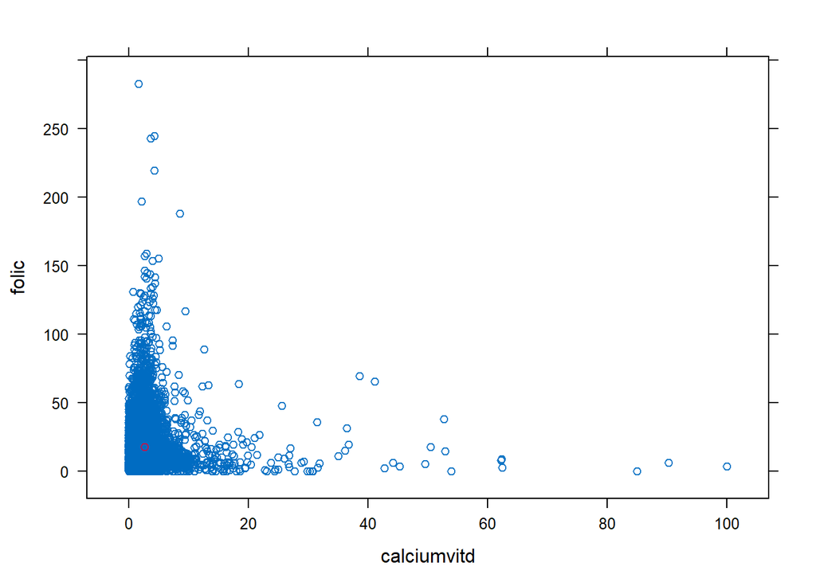

```r
#1. Select the variables from which we will get the average
#calciumvitd and dysldl with more NAs
columns <- c("calciumvitd", "folic")

#2. Create imputation method for the database

nhanes_imputedmean <- mice(nhanes[,names(nhanes) %in% columns],m = 1,maxit = 1, method = "mean",seed = 2018,print=F)

#3. Complete cells by mean

complete.data <- mice::complete(nhanes_imputedmean)

xyplot(nhanes_imputedmean,folic ~calciumvitd)
```

#### **Plot**

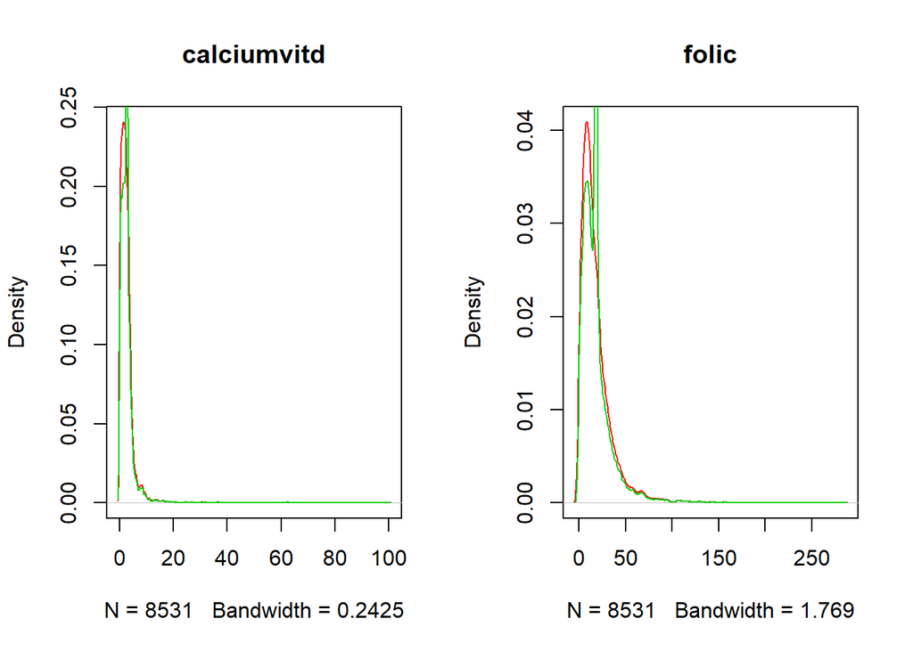

```r
par(mfrow=c(1,2))

plot(density(nhanes$calciumvitd,na.rm = T),col=2,main="calciumvitd")
lines(density(complete.data$calciumvitd),col=3)

plot(density(nhanes$folic,na.rm = T),col=2,main="folic")
lines(density(complete.data$folic),col=3)
```

### 8.4 Imputation by regression

- It incorporates the knowledge of other variables with the idea of producing more sophisticated imputations. The imputed values are the most probable, according to the regression.
- Regression imputation produces unbiased estimates of the means under MCAR, regression weights are unbiased in the MAR if the factors that influence absence are part of the regression model.
- Problems
  - It artificially strengthens the relationships in the data. Regression imputation is a formula for false positive and spurious relationships.
  - Correlations are biased upwards.
  - Variability is underestimated.
  - Imputations are too good to be true.

#### **Imputation**

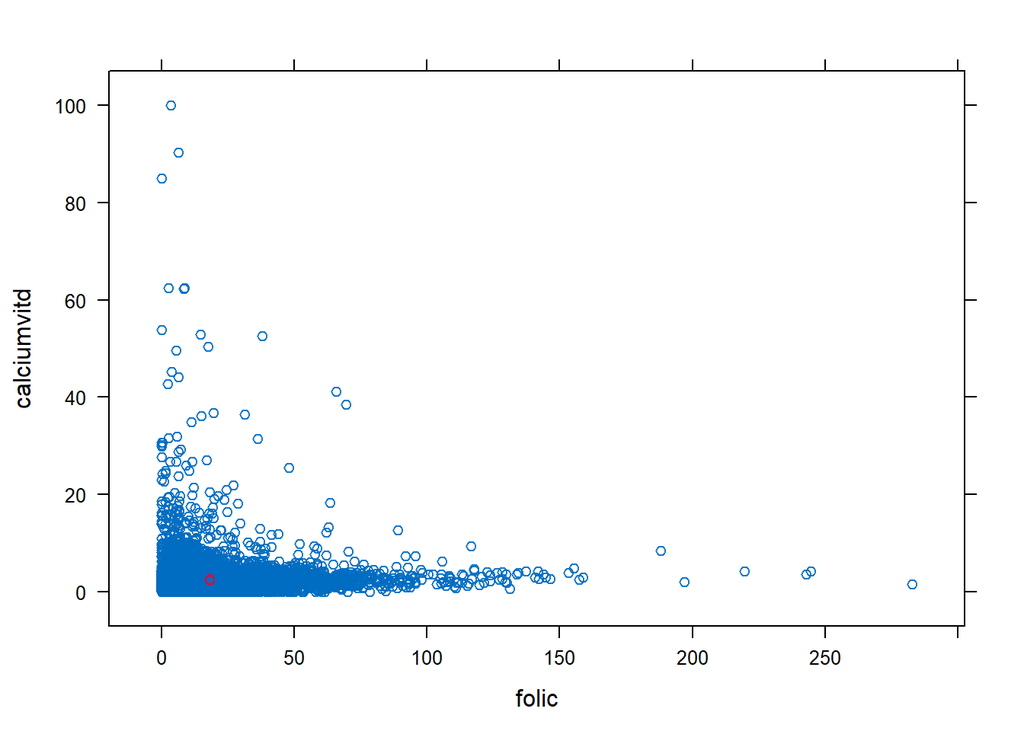

```r
nhanes_impute2  <- mice(nhanes[,names(nhanes) %in% columns],m = 1,
  maxit = 1, method = "norm.predict",seed = 2018,print=F)

nhanes_complete2 <- mice::complete(nhanes_impute2)

xyplot(nhanes_impute2,calciumvitd ~folic)
```

#### **Plot**

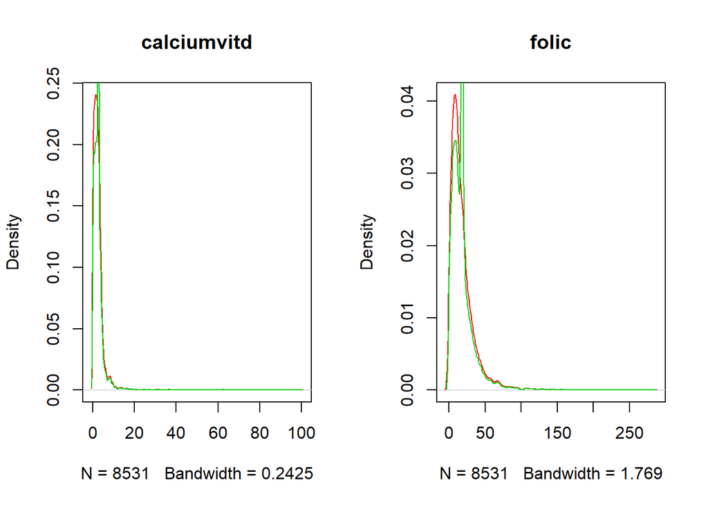

```r
par(mfrow=c(1,2))

plot(density(nhanes$calciumvitd,na.rm = T),col=2,main="calciumvitd")
lines(density(nhanes_complete2$calciumvitd),col=3)

plot(density(nhanes$folic,na.rm = T),col=2,main="folic")
lines(density(nhanes_complete2$folic),col=3)
```

```r
#Similar
```

### 8.5 Imputation by Stochastic regression

- It’s an imputation that adds *noise* to the predictions
- It calculates the intercept, slope and residual variance in the linear model, then calculates the predicted value for each missing value and adds a random draw of the residual to the prediction.
- A well-executed stochastic regression imputation preserves not only the regression weights, but also the correlation between variables.

#### **Imputation**

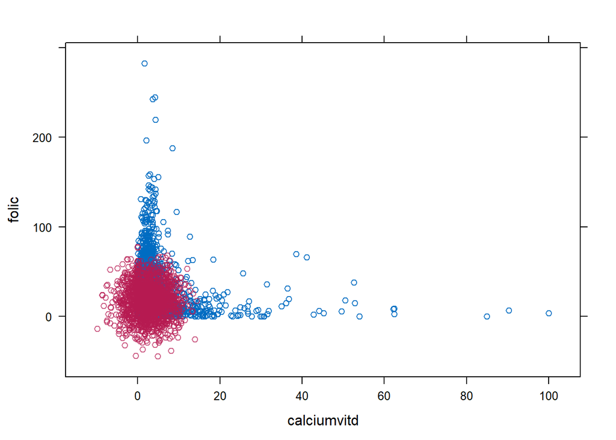

```r
nhanes_impute3 <- mice(nhanes[,names(nhanes) %in% columns],m = 1,
  maxit = 1, method = "norm.nob",seed = 2018,print=F)

nhanes_complete3 <- mice::complete(nhanes_impute3)

xyplot(nhanes_impute3,folic ~ calciumvitd)
```

#### **Plot**

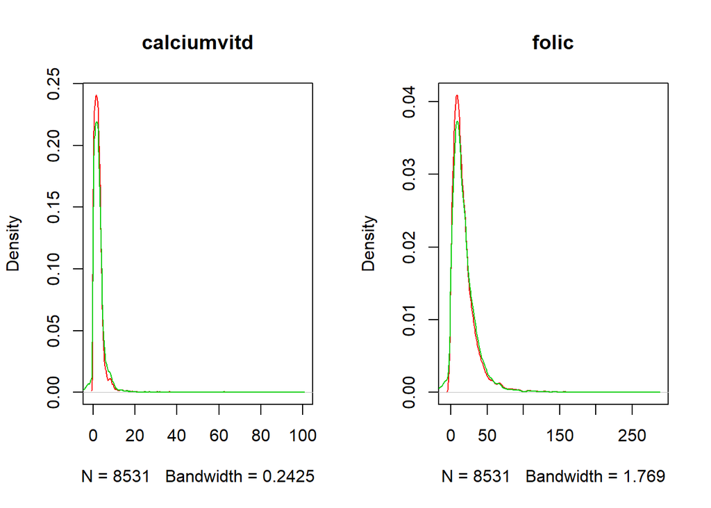

```r
par(mfrow=c(1,2))

plot(density(nhanes$calciumvitd,na.rm = T),col=2,main="calciumvitd")
lines(density(nhanes_complete3$calciumvitd),col=3)

plot(density(nhanes$folic,na.rm = T),col=2,main="folic")
lines(density(nhanes_complete3$folic),col=3)
```

```r
#Better
```

### 8.6 Last Observation Carried Forward

- LOCF is an ad hoc allocation method for longitudinal data.
- The idea is to take the previous observed value as a replacement for the missing data.
- When several values are missing in succession, the method looks for the last observed value.
- To perform this method we will use the package `tidyr`

```r
nhanes_impute4 <- tidyr::fill(nhanes, dysldl)

#Longitudinal data
```

- LOCF is convenient because it generates a complete data set. It can be applied with confidence in cases where we are sure what the missing values should be, for example, for administrative variables in longitudinal data.
- The method has been used for a long time in clinical trials

### 8.6 Multiple imputation

- Multiple allocation creates *m>1* complete data sets.
- Based on the “Rubin rules”, the *m* results are grouped into a final point estimate plus a standard error.
- The figure illustrates the three main steps in multiple imputation: imputation, analysis, and clustering.

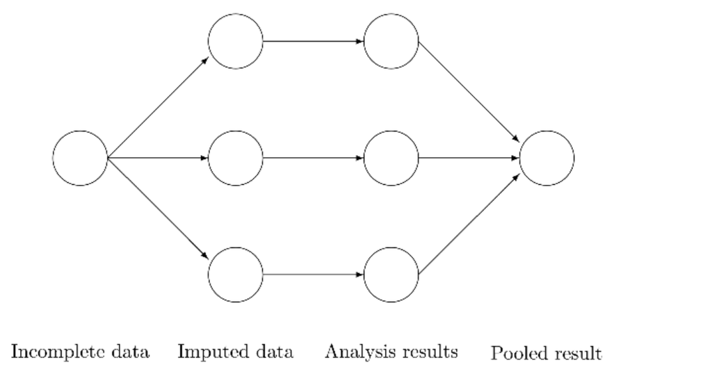

**Steps**

1. Start with observed data that are incomplete (contain ANS). Multiple imputation creates several complete versions of the data by replacing the missing values with plausible data values. These plausible values are extracted from a distribution modeled specifically for each missing cell.
2. Estimate the parameters of interest for each imputed dataset.
3. Join the *m* parameter estimates into a single estimate. Then, a total variance is estimated that combines the variance within and between the imputation.

#### **Imputation**

```r
nhanes_impute5 <- mice(nhanes[,names(nhanes) %in% columns], seed=2018,print = F, m = 30)

nhanes_complete5<- mice::complete(nhanes_impute5)
```

#### **Plot**

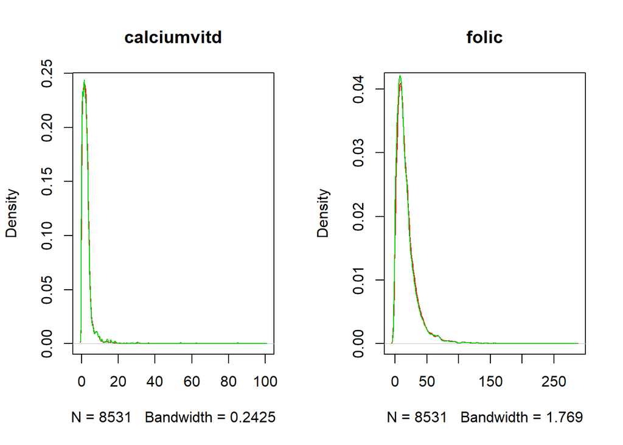

```r
par(mfrow=c(1,2))

plot(density(nhanes$calciumvitd,na.rm = T),col=2,main="calciumvitd")
lines(density(nhanes_complete5$calciumvitd),col=3)

plot(density(nhanes$folic,na.rm = T),col=2,main="folic")
lines(density(nhanes_complete5$folic),col=3)
```

```r
#The best!
```

### 8.7 Random imputation

If we want the imputed data to be defined randomly, we proceed as follows

#### **Imputation**

```r
#It's complex (loop)
nhanes_impute6 <-function(x){

missing <- (is.na(x)) #vector booleano

n.missing <- sum(missing)# NA’s number

x.obs <- x[!missing]# Data frame without NA

imputed <- x

imputed[missing] <- sample(x.obs,n.missing,replace = T)

# Extract a random sample and replace NAs

return(imputed)}

nhanes_complete6 <- nhanes_impute6(nhanes$calciumvitd)
nhanes_complete7 <- nhanes_impute6(nhanes$folic)
```

For more advanced imputation methods, I recommend to visit [Flexible Imputation of Missing Data](https://stefvanbuuren.name/fimd/)

## 9. Processed database generation for analysis

**Nhanes with NAs**

```r
names(nhanes) # Variable name
```

```
##  [1] "id"          "gender"      "dpills"      "calciumvitd" "folic"
##  [6] "dysldl"      "start"       "end"         "treatment"   "HCQ_dosis"
```

```r
dim(nhanes) # check
```

```
## [1] 10175    10
```

**Save processed database**

```r
save(nhanes,file = "nhanes3.RData") #With NA
```